# Työeläkeyhtiön vakavaraisuus, sen kehitys ja tasapainotila

Antti J. Tanskanen, Elinkeinoelämän keskusliitto EK

20.9.2018

# 1 Vakavaraisuus ja sen tasapaino

Tarkastellaan työeläkeyhtiön vakavaraisuutta TyEL-eläkejärjestelmässä. Vakavaraisuuspääoman tehtävänä on toimia viimekätisenä puskurina työeläkeyhtiön sijoitus- ja vakuutustoiminnassa ottamille riskeille. Työeläkeyhtiön vakavaraisuuteen vaikuttavat sijoitustuotot ja vakuutusriskiliike. Hyvitykset maksetaan vakavaraisuudesta. TyELin säännöstö on rakennettu niin, että vakavaraisuuden kasvaessa myös vastuiden tuottovaade kasvaa, mikä alentaa vakavaraisuutta.

Tarkastellaan aluksi vakavaraisuutta järjestelmätasolla. Tasapainovakavaraisuuden voi laskea yhtälöstä, kunhan ensin tekee arvion sijoitustuotoista ja yhtiöiden sijoitusstrategiasta.

Merkitään $w$ yhtiön varoja, $v$ yhtiön vastuita, jolloin yhtiön vakavaraisuus on $s=w-v$. Vakavaraisuusaste määritellään vakavaraisuuspääoman suhteena varoihin

$$S=\frac{w-v}{w}=1-\frac{v}{w}$$
vastuiden täydennyskerroin on

$$R=\max(0.03; \beta(1-\Omega)P)+\Omega(r_o-\lambda),$$
missä $r_o$ on yhtiöiden keskimääräinen osaketuotto vähennettynä tekijällä $\lambda$, missä $\beta=0.18$ on siirtokerroin, $P$ työeläkejärjestelmän täydennysperuste $P=(w-v)/(v)=S/(1-S)$, ja $\Omega=0.2$ on osaketuottosidonnaisuuden aste. Täydennyskerroin määrätään neljännesvuosittain, aina etukäteen yhden vuosineljänneksen verran.

Yksittäiselle työeläkeyhtiölle varat kehittyvät kuten
$$w_{t+1}=(1+\omega_o(S^y)r_o+(1-\omega_o(S^y))r_b)w_t-\gamma(w_t-(P_t+1)v_t)+\delta^y v_t,$$

missä hyvitykset vaikuttavat vakavaraisuuteen ainoastaan siltä osin kuin ne poikkeavat etukäteen arvioidusta järjestelmän keskiarvosta. Työeläkeyhtiöt ottavat tyypillisesti riskiä enemmän, kun vakavaraisuus on hyvä. Portfolio Insurance-sijoitusstrategiassa osakepaino riippuu vakavaraisuudesta

$$\omega_o(S)=\alpha S+\Omega,\quad \omega_b(S)=(1-\Omega)-\alpha S.$$
Toinen tapa sijoittaa on vakioallokaatio
$$\omega_o(S)=\omega_0,\quad \omega_b(S)=\omega_1.$$

Vastuut kehittyvät

$$v_{t+1}=\biggl(1+\frac{\beta(1-\Omega)S_t}{1-S_t}+\Omega(r_o-\lambda)+\delta^y\biggr)v_t,$$
missä nettokassavirta on oletettu vakioksi.

Vakavaraisuus kehittyy
$$S_{t+1}^y=1-\frac{(1+\delta^y+\Omega(r_o-\lambda))(1-S_t)+\beta(1-\Omega)S_t}{(1+\omega_or_o+\omega_br_b-\gamma)(1-S_t)/(1-S^y_t)+\gamma+\delta^y(1-S_t)}$$

# 2 Yksinkertainen koko työeläkejärjestelmää kuvaava malli

Kun summataan $w^y_t$ ja $v_^y_t$ yli kaikkien työeläkelaitosten, saadaan järjestelmätason suureet
$$W_{t+1}=(\omega_or_o+(1-\omega_or_b)W_t+\delta V_t,$$
missä $\delta$ painotettu keskiarvo eri eläkelaitosten nettokassavirroista. Vastuu $V_{t+1}$ vastaavasti
$$V_{t+1}=\biggl(1+\frac{\beta(1-\Omega)S_t}{1-S_t}+\Omega(r_o-\lambda)+\delta\biggr)V_t,$$

Aloitetaan tarkastelu mallista, jossa on vakioitu sijoitusjakauma, nettokassavirta oletetaan nollaksi, eikä hyvityksiä huomioida. Merkitään $\omega_o$ osakepainoa ja $\omega_b$ bondipainoa yhtiön salkussa (unohdetaan muut), ja vastaavia tuottoja $r_o$ ja $r_b$. Tällöin yhtiön varat kehittyvät

$$w_{t+1}=(1+R)w_t,$$

missä on merkitty salkkutuotto $R=\omega_or_o+(1-\omega_o)r_b$ ja vastuu (ilman osittamatonta lisävakuutusvastuuta)

$$v_{t+1}=(1+\beta(1-\Omega)P_t+\Omega(r_o-\lambda))v_t$$
kun $S_t\geq 20.83%$ %.

Tavoite on löytää tasapainotila $S=S_{t+1}=S_{t}$. Tasapainotilassa
$$1-S_{t+1}=\frac{v_{t+1}}{w_{t+1}}=\frac{1+\beta(1-\Omega)P_t+\Omega(r_o-\lambda)}{1+R}\frac{v_t}{w_t}=\frac{\beta(1-\Omega)S_t+(1+\Omega(r_o-\lambda))(1-S_t)}{1+R}.$$
Tasapainossa $S=S_{t+1}=S_{t}$, joten
$$(1+R)(1-S)=\beta(1-\Omega)S+(1+\Omega(r_o-\lambda))(1-S),$$
mistä nähdään että tasapainossa vakavaraisuus $S$ on
$$S=\frac{R-\Omega(r_o-\lambda)}{R+\beta(1-\Omega)-\Omega(r_o-\lambda)}$$

Oletetaan että $\omega_o=0.4$, $\omega_b=0.6$, $r_o=0.08$ ja $r_b=0.04$, jolloin saadaan tasapainovakavaraisuus $S=22.58\%$ (suhteessa varoihin). Tällöin tasapainossa täydennysperuste $P=29.17\%$ (suhteessa vastuisiin).

## 2.1 Konvergoinnin nopeus

Entä konvergenssi? Millä vauhdilla mallin vakavaraisuus konvergoituu kohti tasapainoa? Tehdään vakavaraisuuspääoman muutoksesta jatkuva prosessi, jolloin hieman yksinkertaistaen saamme
$$\frac{d}{dt}w_t=Rw_t, \quad
\frac{d}{dt}v_t=\beta(1-\Omega)(w_t-v_t)+\Omega(r_o-\lambda)v_t.$$
ja vakavaraisuus kehittyy
$$\frac{d}{dt}S_t=\frac{d}{dt}\biggl(1-\frac{v_t}{w_t}\biggr)
=[R-\Omega(r_o-\lambda)]-[R+\beta(1-\Omega)-\Omega(r_o-\lambda)]S_t$$
Ratkaisemalla tämä nähdään, että tasapainossa vakavaraisuus on
$$S_\infty=\frac{R-\Omega(r_o-\lambda)}{R+\beta(1-\Omega)-\Omega(r_o-\lambda)},$$
kuten aiemminkin. Tasapainovakavaraisuutta lähestytään eksponentiaalisesti
$$S_t=S_\infty+(S_0-S_\infty)e^{-Bt},$$
missä $B=R+\beta(1-\Omega)-\Omega(r_o-\lambda)$. Aikaskaalan antaa $\tau=1/B$, joka kertoo missä ajassa ero tasapainoon on pienentynyt $e$:nteen osaan. Yllä käytetyillä esimerkkiparametreillä $\tau=5.38$ vuotta. Toisin sanoen 10 %-yksikön ero tasapainovakavaraisuuteen kutistuisi 3.7 %-yksikköön 5.38 vuodessa. Näin hidas täydennyskertoimen konvergenssi häviää sijoitusmarkkinan heilahteluihin.

# 3 Realistisempi malli

Lisätään mukaan myös vauhti, jolla vastuu nettona kasvaa uuden eläkeoikeuden myötä tai purkautuu eläkkeiden maksamisen myötä. Tätä kutsutaan nettokassavirraksi $\delta v_t$. Tällöin varat kehittyvät
$$w_{t+1}=(1+\omega_o(S)r_o+(1-\omega_o(S))r_b)w_t-\delta v_t$$

ja vastuu

$$v_{t+1}=\biggl(1+\frac{\beta(1-\Omega)S_t}{1-S_t}+\Omega(r_o-\lambda)+\delta\biggr)v_t.$$

Vakavaraisuus kehittyy tällöin
$$1-S_{t+1}=\frac{v_{t+1}}{w_{t+1}}=\frac{\beta(1-\Omega)S_t/(1-S_t)+\Omega(r_o-\lambda)+\delta}{[\omega_o(S)r_o+(1-\omega_o(S))r_b-\gamma]w_t/v_t+\delta+\epsilon\gamma}\\
=\frac{\beta(1-\Omega)S_t/(1-S_t)+\Omega(r_o-\lambda)+\delta}{(\omega_o(S)r_o+(1-\omega_o(S))r_b-\gamma)/(1-S_t)+(\delta+\epsilon\gamma)}\\
=\frac{\beta(1-\Omega)S_t+[\Omega(r_o-\lambda)+\delta](1-S_t)}{(\omega_o(S)r_o+(1-\omega_o(S))r_b-\gamma)+(\delta+\epsilon\gamma)(1-S_t)}$$

Tasapainovakavaraisuuden $S$ saa ratkaistua yhtälöstä
$$1-S=\frac{\beta(1-\Omega)S+[\Omega(r_o-\lambda)+\delta](1-S)}{\alpha S(r_o-r_b)+\Omega r_o+(1-\Omega)r_b-\gamma+(\delta+\epsilon\gamma)(1-S)},$$
jolloin
$$S=\frac{-B+\sqrt{B^2+4AC}}{2A},$$
missä
$$A=\alpha(r_o-r_b)-\delta,\\
B=(\beta+r_b)(1-\Omega)+\Omega\lambda+\delta-\alpha(r_o-r_b),\\
C=\lambda\Omega+(1-\Omega)r_b$$

## 3.1 Tuloksia

Lasketaan näiden tulosten pohjalta, miten vakavaraisuuden tasapaino reagoi erilaisiin järjestelmämuutoksin. Laskelmien parametrit ovat $r_o=0.08, r_b=0.04, \alpha=1, \delta=-0.02, \Omega=0.2, \lambda=0.0, \epsilon=1, \beta=0.18$ ellei toisin mainita.

Nettokassavirta kuvaa sitä virtaavatko varat enemmän vastuuseen (positiivinen) vai sieltä ulos (negatiivinen). Kaikissa pidempään voimassaolleissa eläkejärjestelmissä nettokassavirran tulisi olla negatiivinen, koska niistä maksetaan eläkkeitä enemmän kuin maksutuloa kerätään. Erotus katetaan sijoitustuotoilla. Ellei nettokassavirta olisi negatiivinen, tarkoittaisi tämä että sijoitustoiminnalla hävitettäisiin varoja, eikä kerrytettäisi. Vakavaraisuutta negatiivinen nettokassavirta kasvattaa, koska se kohdistuu euromääräisesti saman suuruisena niin varoihin kuin vastuisiin, mikä johtaa siihen että varojen suhde vastuisiin kasvaa. Tämä siis johtaa korkeampaan tasapainovakavaraisuuteen.

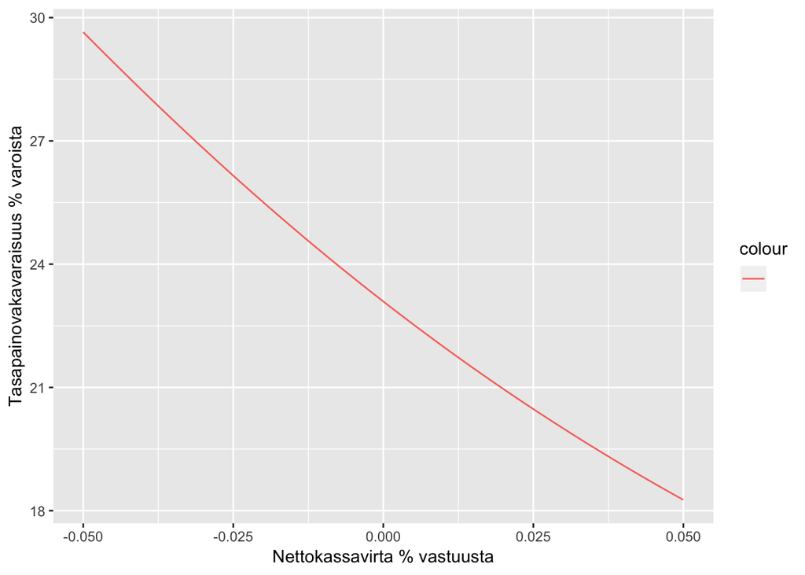

Korkeampi OLV kasvattaa vakavaraisuutta tasapainossa. Tähän on kaksi syytä: (1) tekijä $\lambda$ alentaa tuottovaatimusta, ja (2) täydennyskerroin on muotoa $\beta(1-\Omega)(w_t-v_t)$, missä $\Omega$ on OLV-paino. Jos $\Omega$:aa kasvatetaan, alenee täydennyskerroin.

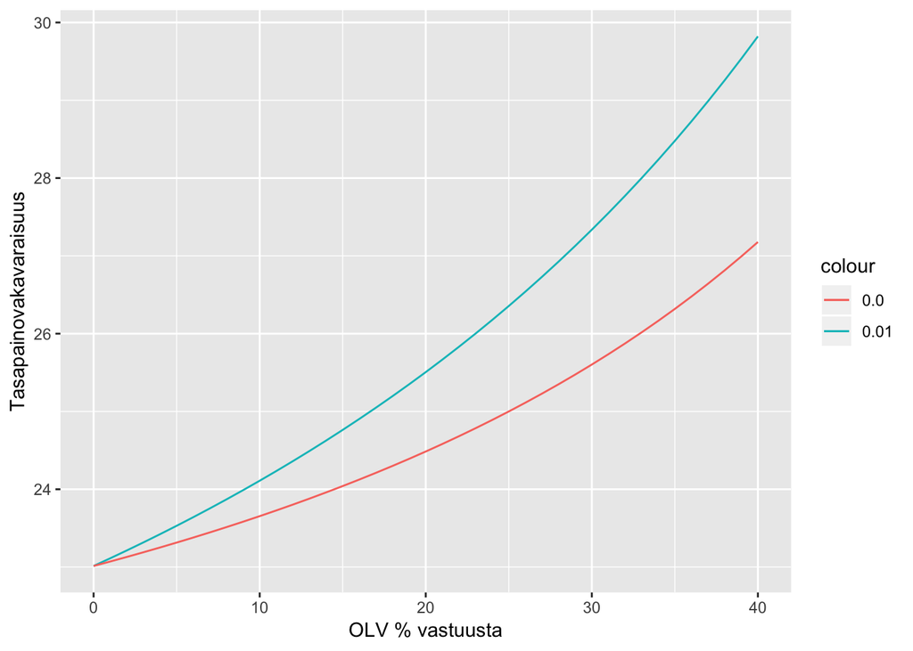

Osaketuotto vaikuttaa selvästi tasapainovakaraisuuteen

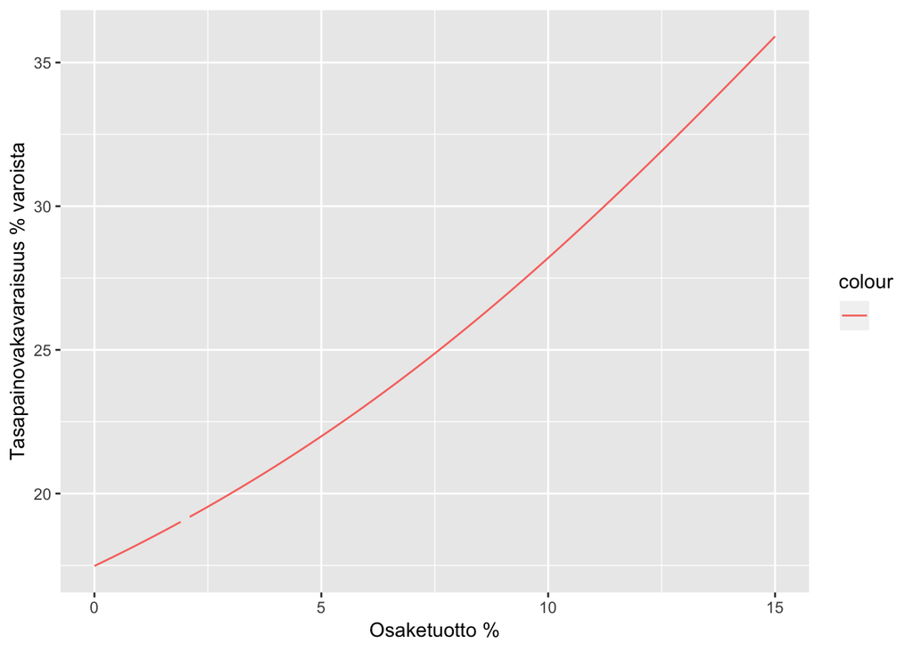

Portfolioinsurancen riskillisyytta kuvaava kerroin $\alpha$ vaikuttaa tasapainon vakavaraisuuteen. Mitä korkeampi $\alpha$ on, sitä enemmän työeläkelaitos ottaa sijoitusriskiä vakavaraisuuden kasvaessa.

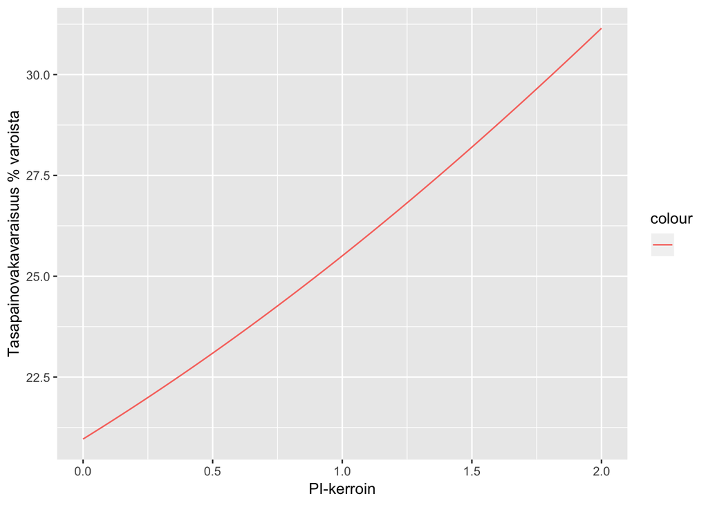

Täydennyskertoimen $\beta$ vaikutus tasapainoon

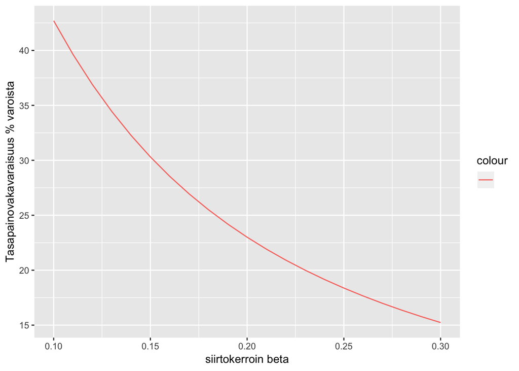

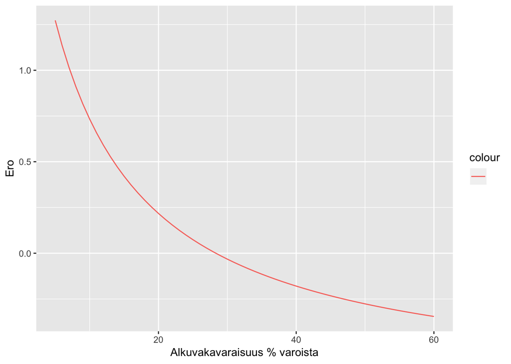

Tasapainovakavaraisuuden avulla on löydettävissä myös Portfolio Insurancen efektiivinen $\alpha$, jonka mukaisella sijoitusstrategialla ko. vakavaraisuus olisi tasapainovakavaraisuus

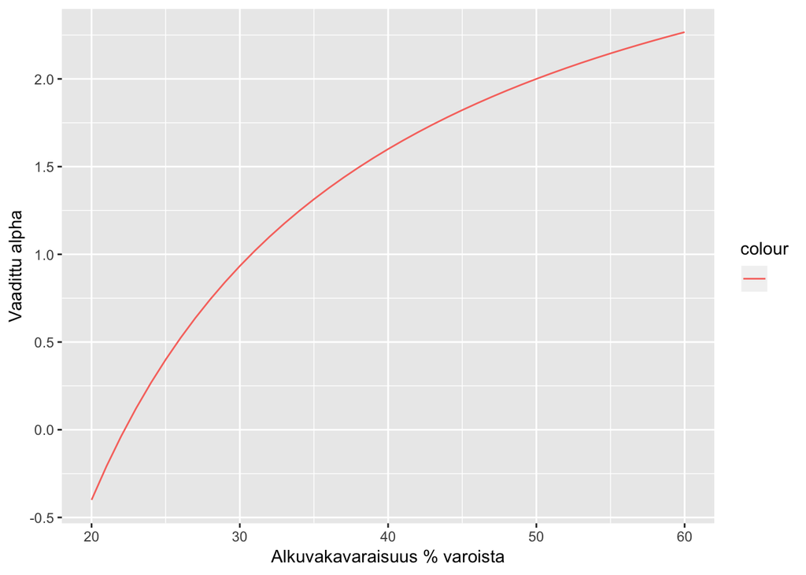

# 4 Erilliset yhtiöt

Tähän asti analyysi on koskenut koko järjestelmää yhtenä monoliittinä. Analysoidaan nyt erillisiä yhtiöitä ja tarkasteltuja vaikutuksia niihin.

Oletetaan $n$ yhtiötä, jolloin niiden varat ovat $w_t^k$, vastuut $v_t^k$ ja vakavaraisuus $S_t^k$, missä $k=1,...,n$. Täydennyskerroin on painotettu keskiarvo
$$R_t=\beta(1-\Omega)\frac{1}{n}\sum_yS^k_t+\Omega r_o$$

## 4.1 Yksinkertainen tapaus

Tarkastellaan aluksi yksinkertaista tapausta, jossa kaikilla yhtiöillä on sama vakioallokaatio sijoituksissa ja nettokassavirta on nolla. Tällöin vakavaraisuuden saa ratkaistua yhtälöstä
$$S^k_{t+1}+1=\frac{\omega_or_o+(1-\omega_o)r_b}{\beta(1-\Omega)S_t+\Omega(r_o-\lambda)}(S^k_t+1),$$
missä on merkitty $S_t=\frac{1}{n}\sum_yS^k_t$. Summaamalla yli $k$:n nähdään että
$$S_{t+1}+1=\frac{\omega_or_o+(1-\omega_o)r_b}{\beta(1-\Omega)S_t+\Omega(r_o-\lambda)}(S_t+1).$$
Toisin sanoen, jos eri työeläkelaitokset ovat samanlaisia ja sijoittavat samoin riippumatta työeläkelaitoksen vakavaraisuudesta, on järjestelmä suoraan lineaarinen. Jos erilaiset vakavaraisuudesta riippuvat sijoitusstrategiat tai nettokassavirrat huomioidaan, näin ei enää käykään.

Realistisemmassa mallissa varat riippuvat yhtiön omasta vakavaraisuudesta, kun taas vastuun kehitys riippuu järjestelmän keskimääräisestä vakavaraisuudesta. Tällöin

$$w_{t+1}=(1+\omega_o(S^y)r_o+(1-\omega_o(S^y))r_b)w_t-\gamma(w_t-\epsilon v_t)+\delta v_t,\\
v_{t+1}=\biggl(1+\frac{\beta(1-\Omega)S_t}{1-S_t}+\Omega(r_o-\lambda)+\delta\biggr)v_t.$$
Siten yhtiön vakavaraisuus kehittyy
$$S^y_{t+1}=1-\frac{v_{t+1}}{w_{t+1}}=1-\frac{1+\beta(1-\Omega)S_t/(1-S_t)+\Omega(r_o-\lambda)+\delta}{(1+\omega_o(S^y)r_o+(1-\omega_o(S^y))r_b+\gamma)/(1-S^y_t)+\epsilon\gamma+\delta}$$

## 4.2 Tuloksia

Se, konvergoiko vakavaraisuus kohti tasapainotilaa riippuu sijoitustuottojen heilunnasta. Jos sijoitussalkun heilunta on voimakasta, voi konvergenssi lähes kadota. Oletetaan 20 prosentin volatiliteetti osakkeille ja 5 prosentin volatiliteetti bondeille. Tällöin vakavaraisuuden kehitys näyttää tältä.

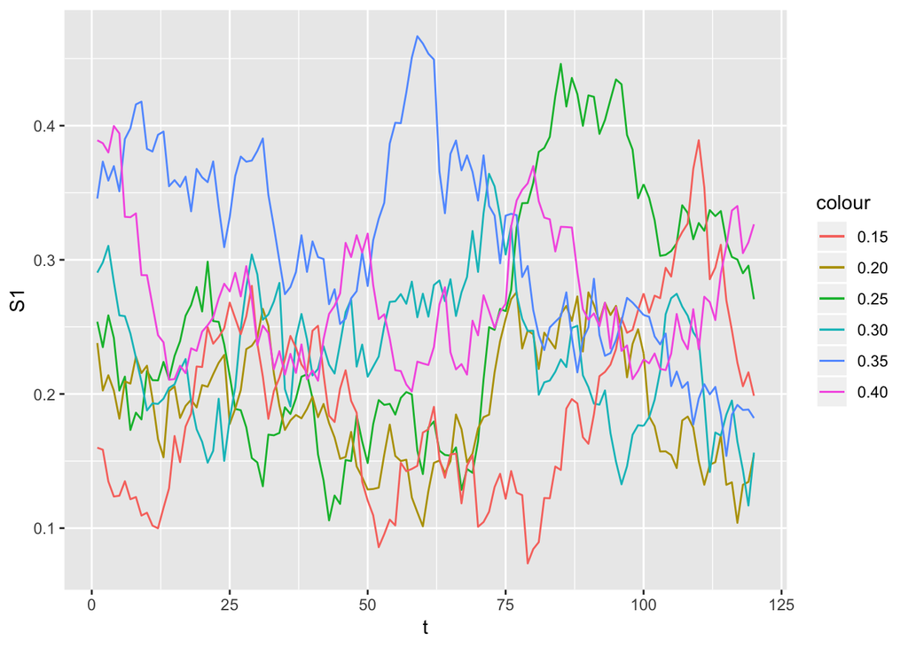

Pienemmillä volatiliteeteillä konvergenssi näkyy selvästi: 5 prosentin osakevolatiliteetti ja 1,2% bondivolatiliteetti

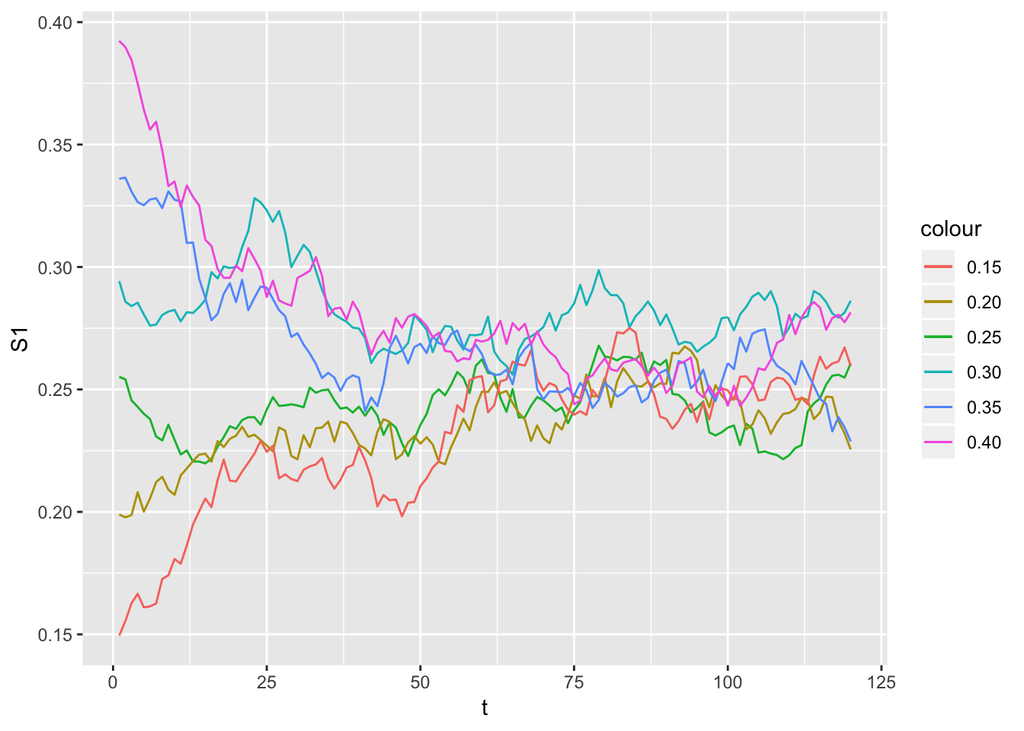

Ja lopuksi ei volatiliteettia lainkaan

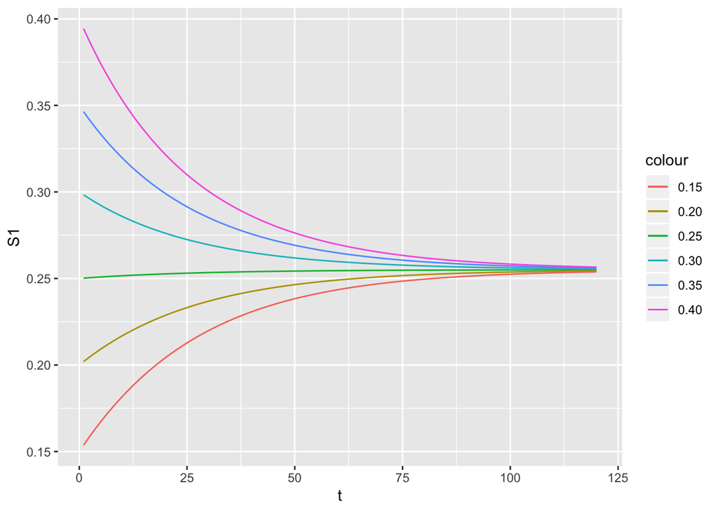

# 5 Yhteenveto

Tämä analyysi ei edes yrittänyt olla analyysi työeläkeyhtiön vakavaraisuudesta, vaan osoitus siitä että kynällä ja paperilla on mahdollista analysoida työeläkeyhtiön vakavaraisuuden kehitystä. Tähän asti useimmat harjoitukset on tehty numeerisesti. Esitetystä analyysistä puuttuu vastuiden tarkempi jaottelu, viiveet tuottovaateessa, tarkempi sijoitustuottomalli yms realistisuutta tuovat tekijät. Tässä tutkimuksessa näytettiin, miten ja millä vauhdilla tuottovaade vie työeläkelaitoksen vakavaraisuutta kohti tasapainotilaa.